# Monopoly

October 31, 2018

## Pregame

- The deluxe hugs video from the Market Structure lecture had a comment to a woman in it that I felt was pretty inappropriate, so I’ve replaced with a different video, but kept the link with an explanation.
- Practice Quiz 2 is up.
- Blackboard organization.
- Writing Assignment update.

## Feedback

### Good:

- Using memes
- Real world examples
- I like that you go over homework in every class, it is actually really helpful!
- I appreciate that you went back over all the previous equations, it was nice to have a refresher!

### Needs improvement:

- Tables with graphs?
- If possible, please post your lectures from when you do not teach class - if I don’t understand something from a sub, this is helpful for me to look back on.
- Please finish the hw problems before the end of class because some people have to leave right at 2pm for another class.

## Imagine you’re Google in the early days of search

The price you charge for ad space is determined by a competitive market, so **you can’t charge any price you want**. You’re a **price-taker**.

[figure not shown]

## Over time, you become more like a monopoly

You choose the price you want, and sell as many as the market will demand at that price. You’re a **price setter**.

[figure not shown]

## The primary difference between a price-taking firm and a monopolist firm

- Price-taking firm faces a demand curve that is market price.
- Monopolist firm faces a demand curve that is the actual demand curve.

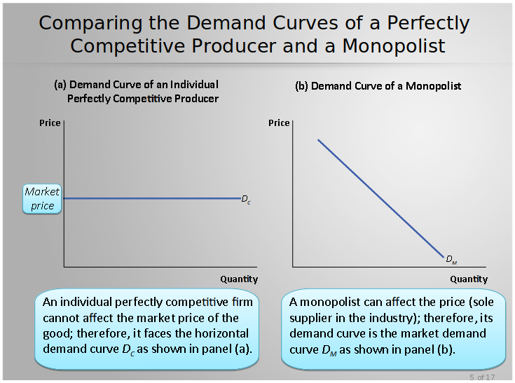

Source: Krugman and Wells

## The primary difference between a price-taking firm and a monopolist firm

The implication is…

## Monopolist maximizes profit across price and quantity

Since choosing the price affects the quantity the monopolist can sell, there are two effects.

For example, if the monopolist increases prices:

- demand is lower so the firm sells less and revenue is reduced. This is the **Quantity Effect**.
- each unit sold is sold at a higher price, so revenue is increased. This is the **Price Effect**.

## Monopolist optimal output

The monopolist chooses quantity at which:

*Marginal Cost is equal to Marginal Revenue (MC = MR), but **not** equal to price.*

In a competitive market, MC = MR = Price, but in a monopoly, the price is higher.

## Monopolist profit

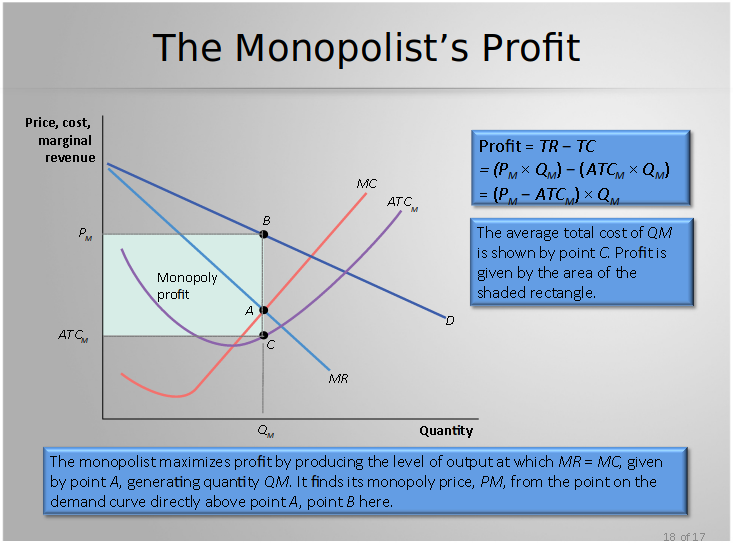

Source: Krugman and Wells

## Raise the price

[figure not shown]

## Google Sheets Example

[Google Sheets](https://docs.google.com/spreadsheets/d/1EdXAIMsQ2JlJ1X7ZbzNfkbXU5yKHWLrvEZDBKlcMhtA/edit?usp=sharing)

## Wrapping Up

- Complete the [knowledge check](https://goo.gl/forms/gElhIUJZRPdRH6Od2) for today’s participation point.
- Please provide [feedback](https://goo.gl/forms/8SiOwdi19kN8cINJ3) on today’s lecture.